# DDS Project1: Budwieser Case Study

Bgaither,Alarsen,Amejia

2/11/2020

**Introduction**

**The Purpose of this analysis is to explore and present to the leadership of Budwieser the following findings:**

**The number of breweries per state in the United States.** **If there is any type of linear relationship to IBU (International Bitterness Unit) and ABV (Alcohol by Volume).** **Explores if there is a difference with respect to IBU and ABV between IPAs (India Pale Ales) and other types of Ale using two different classification techniques.** **If there is a difference in the ABV in different regions of the United States.** **If there is a difference in the IBU for the 12 OZ. and 16 OZ. serving sizes.**

**This document will address the previously stated questions as well as provide the research methodolgy and address assumptions about the data.**

Loading Data into R environment as well as loading the following libraries: ggplot2, car, dplyr, stringr, maps, ggpubr Coercing the ‘state’ column in the US states spatial data to a character to be used downstream

```r
library(ggplot2)
library(car)
library(dplyr)
library(stringr)
library(maps)
library(ggpubr)
dfBeers = read.csv("C:/Users/BGaither/Documents/GitHub/DS_6306/RawDataFiles/Beers.csv",header = TRUE)

dfBreweries = read.csv("C:/Users/BGaither/Documents/GitHub/DS_6306/RawDataFiles/Breweries.csv",header = TRUE)

us_states = read.csv('C:/Users/BGaither/Documents/GitHub/DS_6306/RawDataFiles/states.csv', header = TRUE)

#dfBeers = read.csv(file.choose(),header = TRUE)

#dfBreweries = read.csv(file.choose(),header = TRUE)

#us_states = read.csv(file.choose(), header = TRUE)



us_states['state'] = as.character(us_states$state)
#head(dfBeers)
#head(dfBreweries)
```

**Question of interest: How many breweries are present in each state?**

**Answer:** **The states with the largest amounts of breweries are Colorado, California and Michigan. The states with the fewest amounts of breweries are North Dakota, South Dakota and West Virginia. The states with the largest amounts of breweries tend to be states with moderate to high populations that have strong craft brew scenes. The states with the fewest amounts of breweries tend to be lower population, rural states.**

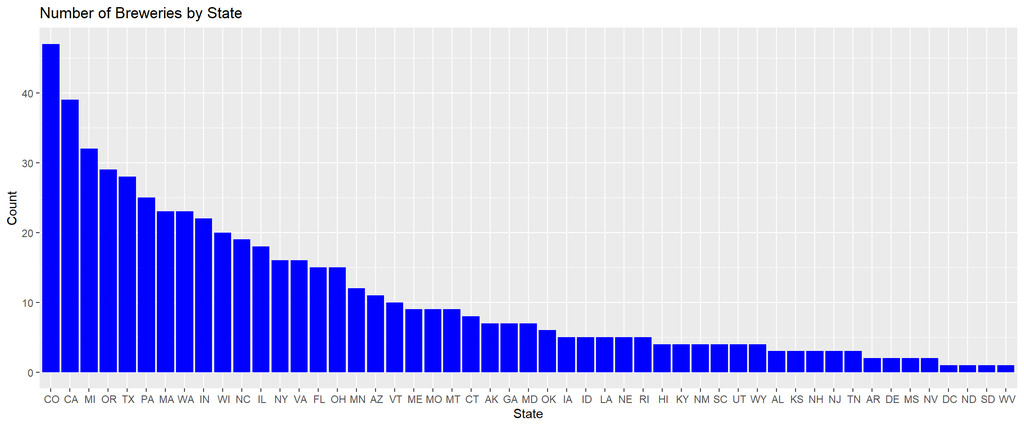

```r
#
data.frame(table(dfBreweries$State)) %>% ggplot(aes(x = State, y = Freq), mapping=aes(x = reorder(Var1, -Freq), y = Freq)) + geom_bar(stat = "Identity", fill="blue") + xlab("State") + ylab("Count") + ggtitle("Number of Breweries by State")
```

```r
#
```

Let’s use the data above to determine how the states make up the total cumulative percent of all breweries using a Pareto Analysis

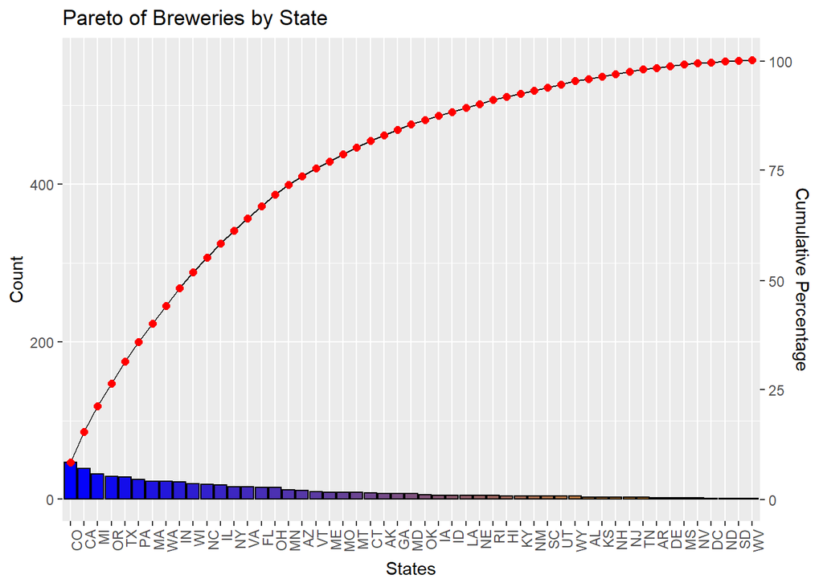

```r
myDF = dfBreweries %>% count(dfBreweries$State)
#descending sort
myDF <- myDF[order(myDF$n, decreasing = TRUE),]
#adding a cumulative sum
myDF$cumulative <- cumsum(myDF$n)
colnames(myDF) <- c("State", "Count", "Cumulative")

library(ggQC)

ggplot(myDF, aes(x=reorder(State, -Count), y=Count)) + geom_bar(stat="identity") + theme(axis.text.x=element_text(angle=90,hjust=1)) + stat_pareto(point.color="red", point.size=2, line.color="black", bars.fill = c("blue", "orange"))+ labs(title = "Pareto of Breweries by State", x='States', y='Count')
```

Merge the individual data frames such that the data set to be used in the analysis

```r
dfFull = left_join(dfBeers, dfBreweries, by= c("Brewery_id"="Brew_ID"))
dfFull['State'] = as.character(str_trim(dfFull$State))
dfFull = left_join(dfFull, us_states, by = c("State" = "state"))
#head(dfFull)
#tail(dfFull)
#dfFull %>% filter(!is.na(IBU))
#to evaluate IPAs against Ales
dfFull["Ales"] = ifelse(grepl("IPA", dfFull$Style),"IPA", ifelse(grepl("Ale", dfFull$Style),"Ale","Other"))
dfFull$Ales = as.factor(dfFull$Ales)
```

Formatting the dataframe

```r
#rename the columns for beer and brewery name
dfFull = dfFull %>% rename(Beer_Name = Name.x, Brewery_Name = Name.y)
#checking to see which columns have NA's
colnames(dfFull)[colSums(is.na(dfFull))>0]
```

```
## [1] "ABV" "IBU"
```

**Question of Interest: How many missing values are in the dataset for ABV and IBU?** **There are 62 Missing values for ABV and 1005 Missing values for IBU**

```r
print(dim(dfFull[is.na(dfFull$ABV),])[1])
```

```
## [1] 62
```

```r
print(dim(dfFull[is.na(dfFull$IBU),])[1])
```

```
## [1] 1005
```

**Question of Interest: Which state has the maximum alcoholic (ABV) beer? Which state has the most bitter (IBU) beer after computing the median IBU and ABV?**

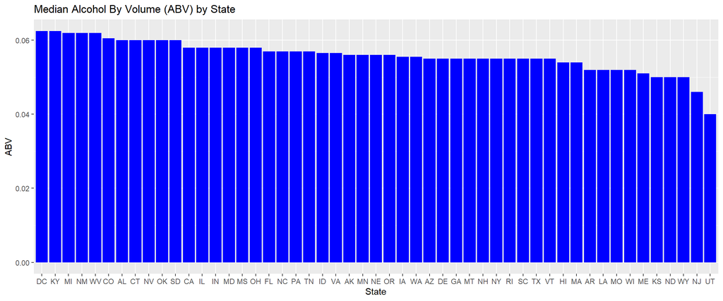

```r
dfIBU = dfFull %>% filter(!is.na(IBU))
dfABV = dfFull %>% filter(!is.na(ABV))
ggplot(data=aggregate(dfABV$ABV, by=list(dfABV$State), FUN=median), mapping=aes(x = reorder(Group.1,-x), y = x)) + geom_bar(stat = "identity", fill="blue") + xlab("State") + ylab("ABV") + ggtitle("Median Alcohol By Volume (ABV) by State")
```

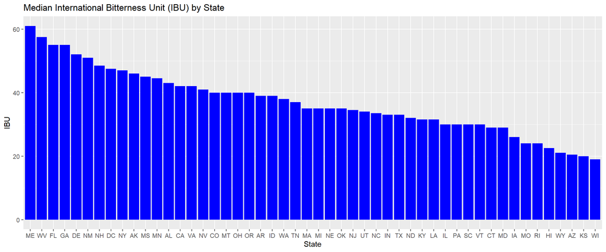

```r
ggplot(data=aggregate(dfIBU$IBU, by=list(dfIBU$State), FUN=median), mapping=aes(x = reorder(Group.1,-x), y = x)) + geom_bar(stat = "identity", fill="blue") + xlab("State") + ylab("IBU") + ggtitle("Median International Bitterness Unit (IBU) by State")
```

Generating map to look at Max Alcohol by Volume by State and Max IBU’s by State

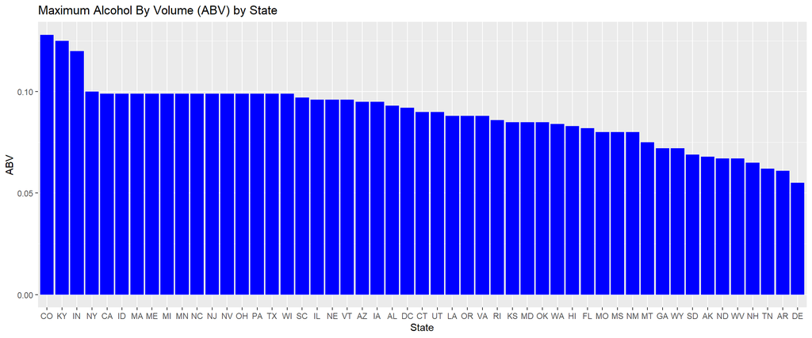

```r
ggplot(data=aggregate(dfABV$ABV, by=list(dfABV$State), FUN=max), mapping=aes(x = reorder(Group.1,-x), y = x)) + geom_bar(stat = "identity", fill="blue") + xlab("State") + ylab("ABV") + ggtitle("Maximum Alcohol By Volume (ABV) by State")
```

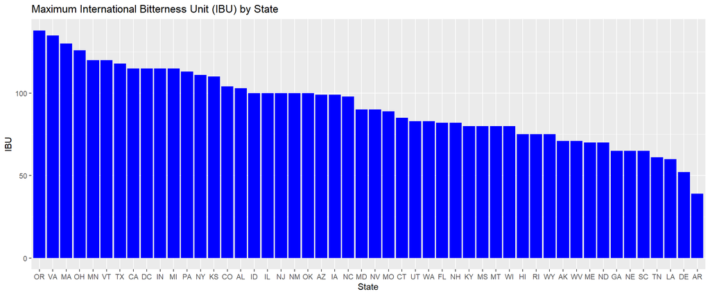

```r
ggplot(data=aggregate(dfIBU$IBU, by=list(dfIBU$State), FUN=max), mapping=aes(x = reorder(Group.1,-x), y = x)) + geom_bar(stat = "identity", fill="blue") + xlab("State") + ylab("IBU") + ggtitle("Maximum International Bitterness Unit (IBU) by State")
```

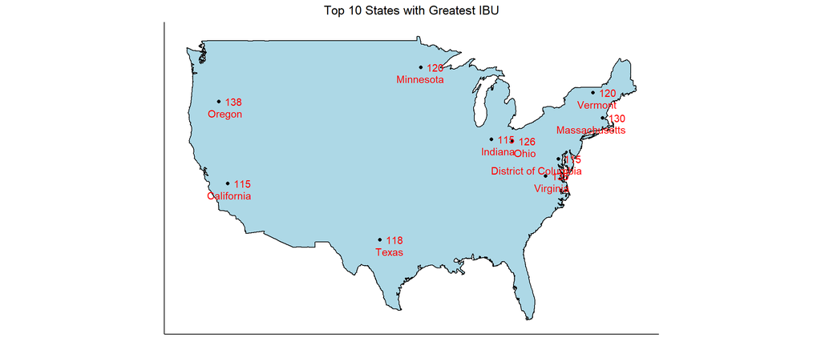

```r
#Mapps of Max IBU by State

usa = map_data("usa")

p <- ggplot() +
  geom_polygon(data = usa, aes(x = long, y = lat, group = group), fill = "lightblue", color = "black") +
  coord_quickmap()

#takes aggregates and labels coordinates

agg = aggregate(dfIBU$IBU, by=list(dfIBU$State), FUN=max)

state_agg = inner_join(agg, us_states, by = c("Group.1" = "state"))

state_agg = state_agg[order(state_agg$x, decreasing = TRUE)[1:10],]

#layers on plots with each state and aggregate


p + geom_point(data = state_agg, aes(x = longitude, y = latitude)) + geom_text(data = state_agg, aes(x = longitude, y = latitude, label = x), hjust = 0 , nudge_x = 0.75, color = "red" )+
   geom_text(data = state_agg, aes(x = longitude, y = latitude, label = name), hjust = 1 , nudge_x = 3, nudge_y = -1, color = "red" )+
  coord_fixed(1.50) + # fix lat/long display ratio
  ggtitle("Top 10 States with Greatest IBU") + theme_bw() + theme(plot.title = element_text(hjust = 0.5)) +  theme(panel.border = element_blank(), panel.grid.major = element_blank(), panel.grid.minor = element_blank(), axis.line = element_line(colour = "Black")) +
  theme(legend.position = "none",
        axis.title.x=element_blank(), # hide x axis title
        axis.text.x=element_blank(),  # hide x axis text
        axis.ticks.x=element_blank(), # hide x axis ticks
        axis.title.y=element_blank(), # hide y axis title
        axis.text.y=element_blank(),  # hide y axis text
        axis.ticks.y=element_blank()) # hide y axis ticks
```

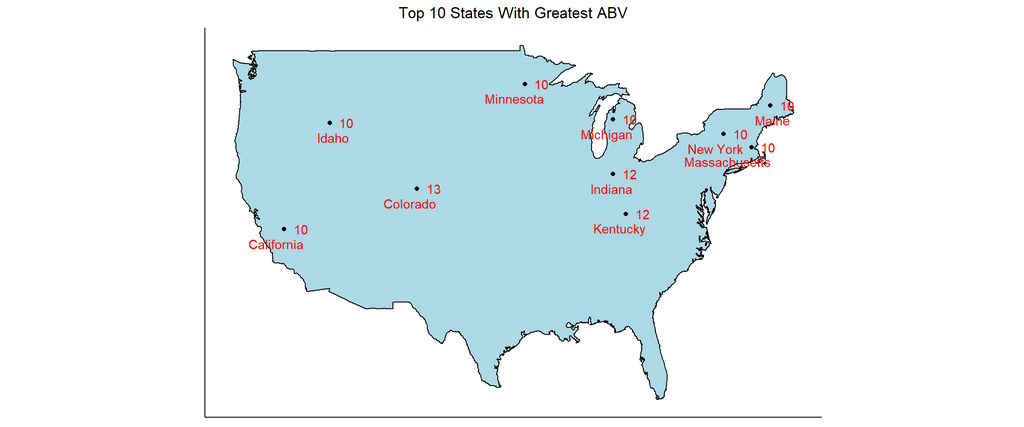

```r
agg = aggregate(dfABV$ABV, by=list(dfABV$State), FUN=max)

state_agg = inner_join(agg, us_states, by = c("Group.1" = "state"))

state_agg = state_agg[order(state_agg$x, decreasing = TRUE)[1:10],]


p + geom_point(data = state_agg, aes(x = longitude, y = latitude)) + geom_text(data = state_agg, aes(x = longitude, y = latitude, label = round((x*100)), digits = 3), hjust = 0 , nudge_x = 1, color = "red" )+
   geom_text(data = state_agg, aes(x = longitude, y = latitude, label = name), hjust = 1 , nudge_x = 2, nudge_y = -1, color = "red" )+
  coord_fixed(1.50) + # fix lat/long display ratio
  ggtitle("Top 10 States With Greatest ABV") + theme_bw() + theme(plot.title = element_text(hjust = 0.5)) +  theme(panel.border = element_blank(), panel.grid.major = element_blank(), panel.grid.minor = element_blank(), axis.line = element_line(colour = "Black")) +
  theme(legend.position = "none",
        axis.title.x=element_blank(), # hide x axis title
        axis.text.x=element_blank(),  # hide x axis text
        axis.ticks.x=element_blank(), # hide x axis ticks
        axis.title.y=element_blank(), # hide y axis title
        axis.text.y=element_blank(),  # hide y axis text
        axis.ticks.y=element_blank()) # hide y axis ticks
```

**Question of Interest: Comment on the Summary Statistics of ABV and its Distribution**

**ABV Distribution + Summary Statistics**

```r
summary(dfABV$ABV)
```

```
##    Min. 1st Qu.  Median    Mean 3rd Qu.    Max.
## 0.00100 0.05000 0.05600 0.05977 0.06700 0.12800
```

**Answer:** **We would like to get a better understanding of the distribution of ABV to get a sense of what ABV most beers contain. The majority of beers contain ~.05 ABV**

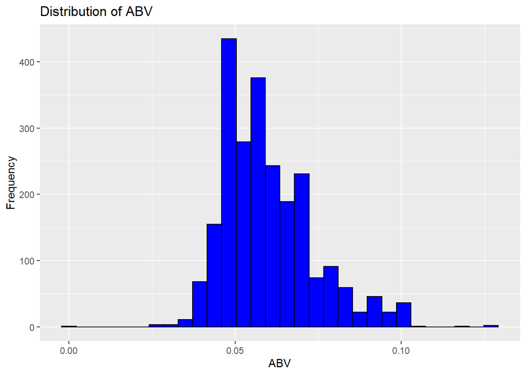

```r
ggplot(dfABV, aes(x=dfABV$ABV)) + geom_histogram(colour="black", fill="blue") + xlab("ABV") + ylab("Frequency") + ggtitle("Distribution of ABV")
```

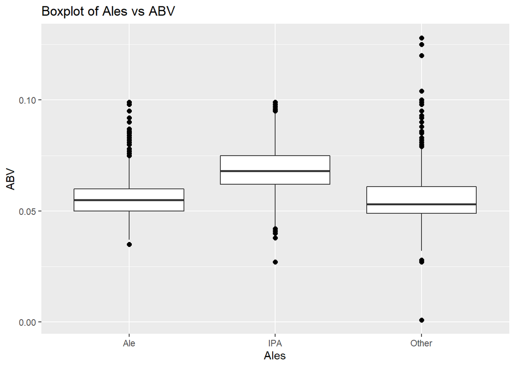

```r
ggplot(dfABV, aes(x=dfABV$Ales, y=dfABV$ABV)) + geom_boxplot(outlier.color="black", outlier.shape=16, outlier.size=2, notch=FALSE)+ ggtitle("Boxplot of Ales vs ABV")+ xlab("Ales") + ylab("ABV")
```

**Question of Interest: is there an apparent relationship between the bitterness of the beer and its alcoholic content? Draw a scatter plot. Make your best judgment of a relationship?**

**Answer:** **We would like to investigate whether there is a relationship between ABV and IBU. To start out, we have created a scatterplot of ABV to IBU to look for visual indication of a relationship. We also checked by logging the variables to see if the relationship observed increased. There does appear to be a slight positive linear relationship, but we’ll continue our analysis by checking the correlation of these variables next.**

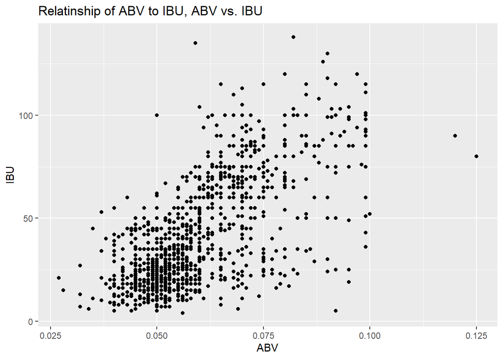

```r
dfRM = na.omit(dfFull)
dfRM["Log_IBU"] = log(dfRM$IBU)
dfRM["Log_ABV"] = log(dfRM$ABV)
dfRM["Logit_ABV"] = logit(dfRM$ABV)
ggplot(data = dfRM, mapping = aes(x = dfRM$ABV, y = dfRM$IBU )) + geom_point() + xlab("ABV") + ylab("IBU") + ggtitle("Relatinship of ABV to IBU, ABV vs. IBU")
```

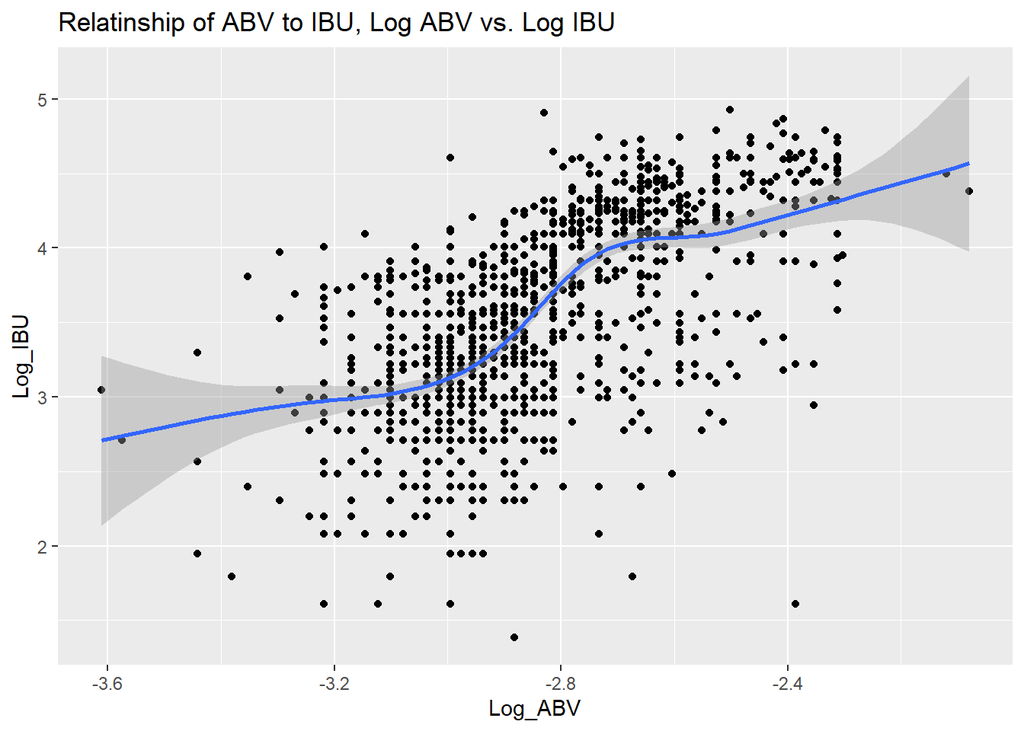

```r
ggplot(data = dfRM, mapping = aes(x = dfRM$Log_ABV, y = dfRM$Log_IBU )) + geom_point() + xlab("Log_ABV") + ylab("Log_IBU") + ggtitle("Relatinship of ABV to IBU, Log ABV vs. Log IBU") + geom_smooth()
```

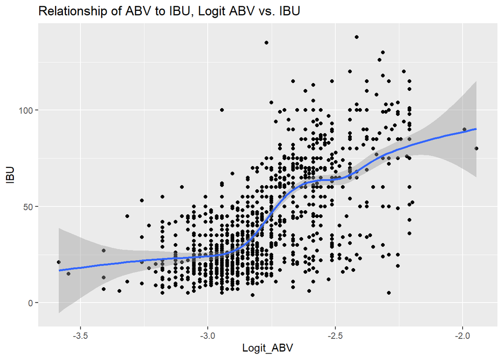

```r
ggplot(data = dfRM, mapping = aes(x = dfRM$Logit_ABV, y = dfRM$IBU )) + geom_point() + xlab("Logit_ABV") + ylab("IBU") + ggtitle("Relationship of ABV to IBU, Logit ABV vs. IBU") + geom_smooth()
```

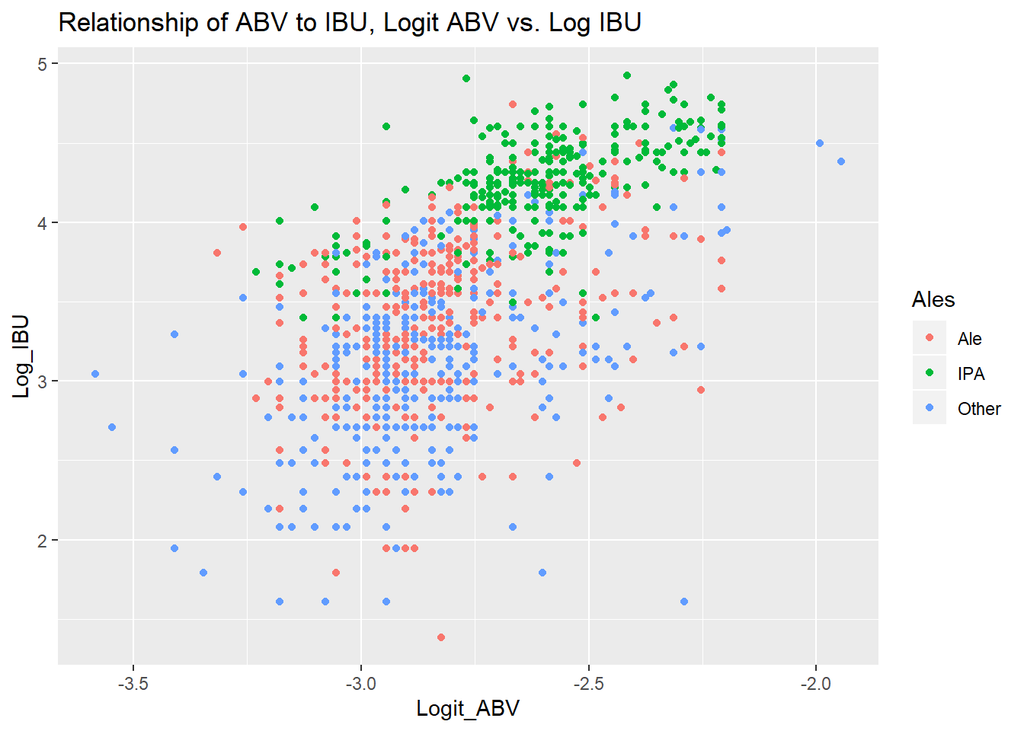

```r
ggplot(data = dfRM, mapping = aes(x = dfRM$Logit_ABV, y = dfRM$Log_IBU, color = Ales)) + geom_point() + xlab("Logit_ABV") + ylab("Log_IBU") + ggtitle("Relationship of ABV to IBU, Logit ABV vs. Log IBU")
```

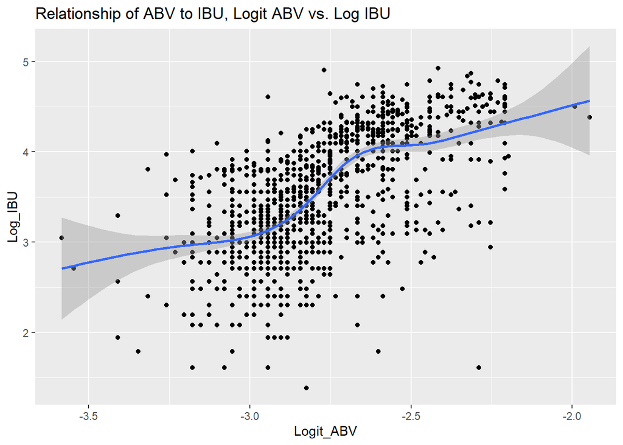

```r
ggplot(data = dfRM, mapping = aes(x = dfRM$Logit_ABV, y = dfRM$Log_IBU)) + geom_point() + xlab("Logit_ABV") + ylab("Log_IBU") + ggtitle("Relationship of ABV to IBU, Logit ABV vs. Log IBU") + geom_smooth()
```

**Question of Interest: Is there an apparent relationship between the bitterness of the beer and its alcoholic content?**

**Answer:**

**We would like to investigate if there is a relationship between the bitterness of the beer and it’s alcoholic content while at the same time trying to identify a relationship between Ales, IPA’s and other styles of beer. Looking at the relationship of ABV and IBU to Ales, IPA and other style of beer we can see there is a positive correlation between ABV and IBU and we can also see evidence of clusters around the styles of beer. To do this in a more formal manner, we perform a pearson correlation between the two variables. The result is a positive correlation with a pearsons correlation value of 0.671.**

```r
library(GGally)
```

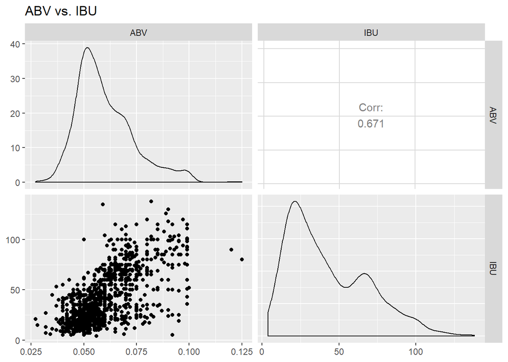

```r
dfRM %>%
select(ABV, IBU) %>%
ggpairs(title = "ABV vs. IBU")
```

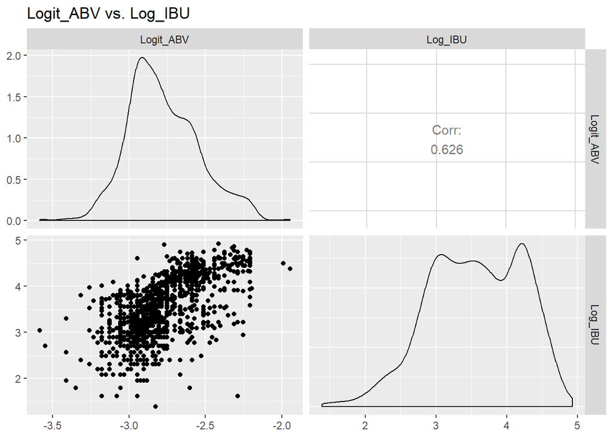

```r
dfRM %>% select(Logit_ABV, Log_IBU) %>% ggpairs(title = "Logit_ABV vs. Log_IBU")
```

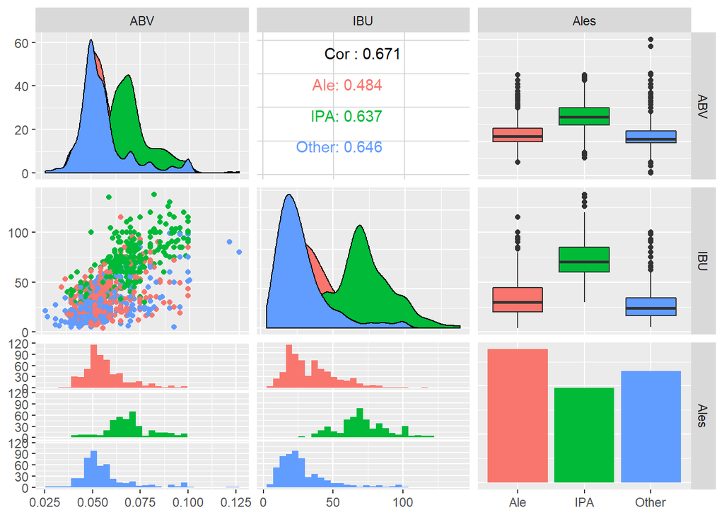

```r
dfRM %>%
select(ABV, IBU, Ales) %>%
ggpairs(aes(color = Ales))
```

```r
#Adding output from Pearson's product moment correlation test

cor.test(dfRM$ABV, dfRM$IBU, method=c("pearson", "kendall", "spearman"))
```

```
##
##  Pearson's product-moment correlation
##
## data:  dfRM$ABV and dfRM$IBU
## t = 33.863, df = 1403, p-value < 2.2e-16
## alternative hypothesis: true correlation is not equal to 0
## 95 percent confidence interval:
##  0.6407982 0.6984238
## sample estimates:
##       cor
## 0.6706215
```

**Question of Interest: Is there a difference with respect to IBU and ABV between IPAs (India Pale Ales) and other types of Ale (any beer with “Ale” in its name other than IPA)?**

**Answer:**

**We would like to investigate the difference with respect to IBU and ABV between IPAs and other types of Ale. To do this, we will construct both a KNN (k- Nearest Neighbor) model and NBB (Nieve-Bayes)we construct a dataframe to include only the ABV, IBU and Ales indicator, excluding missing values, to build a training and test set for further analysis.**

```r
library(dplyr)

set.seed(6)
splitPerc = .75

dfAles = dfRM %>% filter(Ales == "Ale" | Ales == "IPA")
dfAles = dfAles %>% select(ABV,IBU,Ales)
summary(dfAles)
```

```
##       ABV               IBU            Ales
##  Min.   :0.03500   Min.   :  4.00   Ale  :552
##  1st Qu.:0.05200   1st Qu.: 27.00   IPA  :392
##  Median :0.06000   Median : 45.00   Other:  0
##  Mean   :0.06178   Mean   : 49.95
##  3rd Qu.:0.07000   3rd Qu.: 70.00
##  Max.   :0.09900   Max.   :138.00
```

```r
dfAles = droplevels(dfAles,exclude = "Other")
summary(dfAles)
```

```
##       ABV               IBU          Ales
##  Min.   :0.03500   Min.   :  4.00   Ale:552
##  1st Qu.:0.05200   1st Qu.: 27.00   IPA:392
##  Median :0.06000   Median : 45.00
##  Mean   :0.06178   Mean   : 49.95
##  3rd Qu.:0.07000   3rd Qu.: 70.00
##  Max.   :0.09900   Max.   :138.00
```

```r
trainIndices = sample(1:dim(dfAles)[1],round(splitPerc * dim(dfAles)[1]))
train = dfAles[trainIndices,]
test = dfAles[-trainIndices,]
colnames(dfAles)[colSums(is.na(dfAles))>0]
```

```
## character(0)
```

**Next, we want to iterate through multiple classification attempts where we test with k=1 to 30 to determine the optimal k value. The result is that the optimal k value is 5 as can be seen in the resulting chart.**

```r
library(class)
library(caret)
```

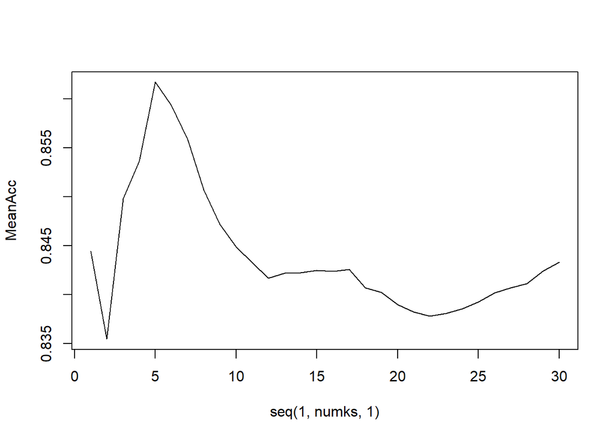

```r
library(e1071)

iterations = 500
numks = 30

masterAcc = matrix(nrow = iterations, ncol = numks)

for(j in 1:iterations)
{
accs = data.frame(accuracy = numeric(30), k = numeric(30))
trainIndices = sample(1:dim(dfAles)[1],round(splitPerc * dim(dfAles)[1]))
train = dfAles[trainIndices,]
test = dfAles[-trainIndices,]
for(i in 1:numks)
{
  classifications = knn(train[,c("ABV", "IBU")],test[,c("ABV", "IBU")],train$Ales, prob = TRUE, k = i)
  table(classifications,test$Ales)
  CM = confusionMatrix(table(classifications,test$Ales))
  masterAcc[j,i] = CM$overall[1]
}

}

MeanAcc = colMeans(masterAcc)

plot(seq(1,numks,1),MeanAcc, type = "l")
```

**Now that we know the optimum k value is 5, we run the KNN with k=5.**

**We can see below that we can classify Ales and IPA’s by their ABV and IBU values with an accuracy of 87%. We also created a NBB model using the same dataset**

```r
trainIndices = sample(1:dim(dfAles)[1],round(splitPerc * dim(dfAles)[1]))
train = dfAles[trainIndices,]
test = dfAles[-trainIndices,]

# k = 5
classifications = knn(train[,c("ABV", "IBU")],test[,c("ABV", "IBU")],train$Ales, prob = TRUE, k = 5)
table(test$Ales,classifications)
```

```
##      classifications
##       Ale IPA
##   Ale 120  13
##   IPA  17  86
```

```r
confusionMatrix(table(test$Ales,classifications))
```

```
## Confusion Matrix and Statistics
##
##      classifications
##       Ale IPA
##   Ale 120  13
##   IPA  17  86
##
##                Accuracy : 0.8729
##                  95% CI : (0.8235, 0.9126)
##     No Information Rate : 0.5805
##     P-Value [Acc > NIR] : <2e-16
##
##                   Kappa : 0.7405
##
##  Mcnemar's Test P-Value : 0.5839
##
##             Sensitivity : 0.8759
##             Specificity : 0.8687
##          Pos Pred Value : 0.9023
##          Neg Pred Value : 0.8350
##              Prevalence : 0.5805
##          Detection Rate : 0.5085
##    Detection Prevalence : 0.5636
##       Balanced Accuracy : 0.8723
##
##        'Positive' Class : Ale
##
```

```r
### NB model

model_2 = naiveBayes(train[,c("ABV", "IBU")],train$Ales)
table_cm = table(predict(model_2, test[,c("ABV", "IBU")]), test$Ales)
CM = confusionMatrix(table_cm)
CM
```

```
## Confusion Matrix and Statistics
##
##
##       Ale IPA
##   Ale 117  17
##   IPA  16  86
##
##                Accuracy : 0.8602
##                  95% CI : (0.8093, 0.9018)
##     No Information Rate : 0.5636
##     P-Value [Acc > NIR] : <2e-16
##
##                   Kappa : 0.7154
##
##  Mcnemar's Test P-Value : 1
##
##             Sensitivity : 0.8797
##             Specificity : 0.8350
##          Pos Pred Value : 0.8731
##          Neg Pred Value : 0.8431
##              Prevalence : 0.5636
##          Detection Rate : 0.4958
##    Detection Prevalence : 0.5678
##       Balanced Accuracy : 0.8573
##
##        'Positive' Class : Ale
##
```

**Additional Insights:**

**Quetion of Interest: Is there a difference in the size of beer and region the beer came from and do they effect ABV or IBU?**

**Answer**:

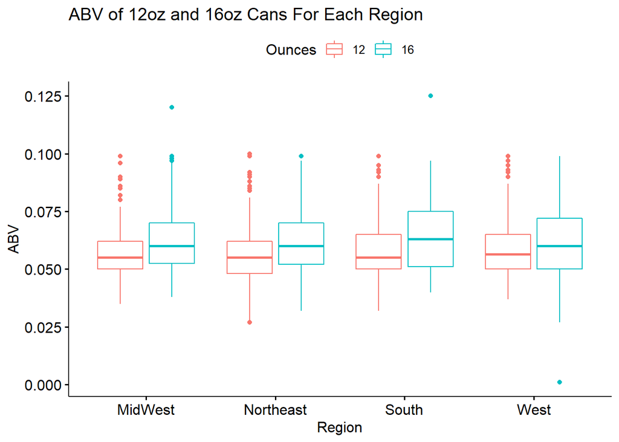

```r
## Question 9: Data parsing + Box plots
dfFull$Ounces = as.factor(dfFull$Ounces)
dfFull$State = as.character(dfFull$State)
# Cut state into 4 regions
dfFull$Region = Recode(dfFull$State, "c('CT', 'ME', 'MA', 'NH', 'RI', 'VT', 'NJ', 'NY', 'PA') ='Northeast'; c('OH','IN','IL','MI','WI','MN','IA','MO','KS','NE','SD','ND') = 'MidWest'; c('TX','OK','AR','LA','MS','AL','TN','KY','WV','MD','DC','DE','VA','NC','SC', 'GA','FL') = 'South'; c('HI','AK') = 'Pacific'; c('NM','CO','WY','MT','ID','UT','AZ','NV','CA','OR','WA') = 'West'")
dfFull$Region = as.factor(dfFull$Region)

# Use only 12 and 16 ounce beers
dfFull = dfFull[dfFull$Ounces == 12 | dfFull$Ounces == 16,]
dfFull = dfFull[dfFull$Region != 'Pacific',]
# my summary for use with boxplots
mysummary<-function(x){
  result<-c(length(x),mean(x),sd(x),sd(x)/sqrt(length(x)), min(x), max(x), IQR(x))
  names(result)<-c("N","Mean","SD","SE", "Min", "Max", "IQR")
  return(result)
}
# Create boxplots for both ABV and IBU
dfABV = dfFull %>% filter(!is.na(ABV))
ggboxplot(dfABV, x="Region", y="ABV", color="Ounces", pallette = c("#00AFBB", "#E7B800"))+
ggtitle("ABV of 12oz and 16oz Cans For Each Region")
```

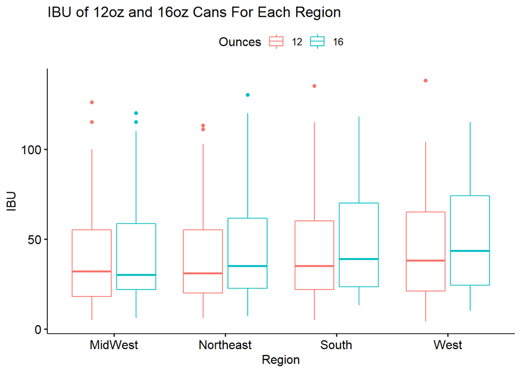

```r
dfIBU = dfFull %>% filter(!is.na(IBU))
ggboxplot(dfIBU, x="Region", y="IBU", color="Ounces", pallette = c("#00AFBB", "#E7B800"))+
ggtitle("IBU of 12oz and 16oz Cans For Each Region")
```

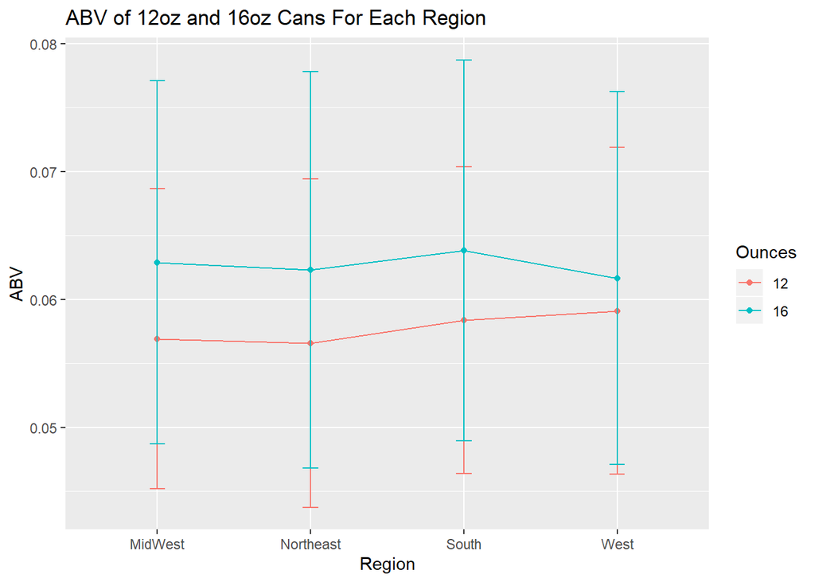

```r
# Create line graphs with standard deviation bars
ABVsumstats<-aggregate(ABV~Region*Ounces,data=dfABV,mysummary)
ABVsumstats<-cbind(ABVsumstats[,1:2],ABVsumstats[,-(1:2)])

ggplot(ABVsumstats,aes(x=Region,y=Mean,group=Ounces,colour=Ounces))+
  ylab("ABV")+
  geom_line()+
  geom_point()+
  ggtitle("ABV of 12oz and 16oz Cans For Each Region")+
  geom_errorbar(aes(ymin=Mean-SD,ymax=Mean+SD),width=.1)
```

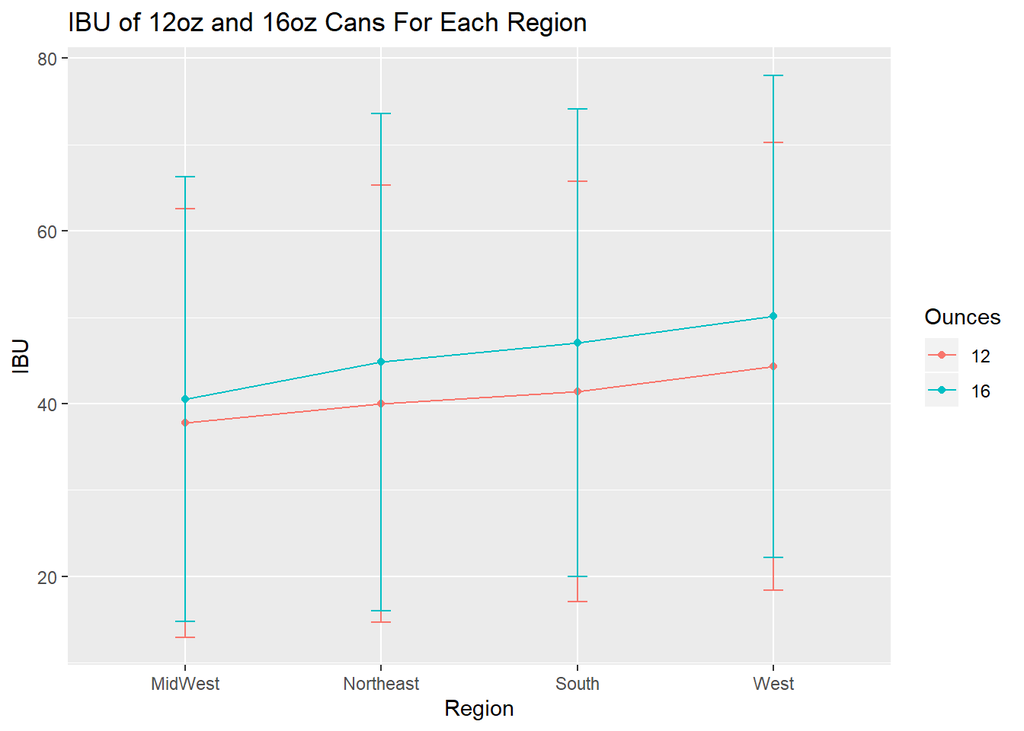

```r
# Line graph with IBU
IBUsumstats<-aggregate(IBU~Region*Ounces,data=dfIBU,mysummary)
IBUsumstats<-cbind(IBUsumstats[,1:2],IBUsumstats[,-(1:2)])

ggplot(IBUsumstats,aes(x=Region,y=Mean,group=Ounces,colour=Ounces))+
  ylab("IBU")+
  geom_line()+
  geom_point()+
  ggtitle("IBU of 12oz and 16oz Cans For Each Region")+
  geom_errorbar(aes(ymin=Mean-SD,ymax=Mean+SD),width=.1)
```

```r
# Run two-way ANOVA
res.aov <- aov(dfIBU$IBU ~ dfIBU$Region + dfIBU$Ounces + dfIBU$Region:dfIBU$Ounces)
summary(res.aov)
```

```
##                             Df Sum Sq Mean Sq F value  Pr(>F)
## dfIBU$Region                 3  10248    3416   5.108 0.00162 **
## dfIBU$Ounces                 1   6241    6241   9.332 0.00230 **
## dfIBU$Region:dfIBU$Ounces    3    504     168   0.251 0.86054
## Residuals                 1344 898819     669
## ---
## Signif. codes:  0 '***' 0.001 '**' 0.01 '*' 0.05 '.' 0.1 ' ' 1
```

```r
#IBU comparisons
TukeyHSD(res.aov)
```

```
##   Tukey multiple comparisons of means
##     95% family-wise confidence level
##
## Fit: aov(formula = dfIBU$IBU ~ dfIBU$Region + dfIBU$Ounces + dfIBU$Region:dfIBU$Ounces)
##
## $`dfIBU$Region`
##                       diff        lwr       upr     p adj
## Northeast-MidWest 2.189423 -3.6178264  7.996672 0.7666943
## South-MidWest     3.372305 -1.8936125  8.638222 0.3524380
## West-MidWest      6.777855  2.2158294 11.339881 0.0007983
## South-Northeast   1.182882 -4.9490317  7.314795 0.9599376
## West-Northeast    4.588433 -0.9507517 10.127617 0.1438849
## West-South        3.405551 -1.5631816  8.374283 0.2917708
##
## $`dfIBU$Ounces`
##           diff      lwr      upr     p adj
## 16-12 4.338582 1.452593 7.224571 0.0032419
##
## $`dfIBU$Region:dfIBU$Ounces`
##                                 diff         lwr       upr     p adj
## Northeast:12-MidWest:12    2.2466132  -6.7318191 11.225045 0.9950075
## South:12-MidWest:12        3.6523650  -4.4206699 11.725400 0.8693574
## West:12-MidWest:12         6.5642336  -0.8258389 13.954306 0.1244475
## MidWest:16-MidWest:12      2.7787366  -5.4135772 10.971050 0.9699606
## Northeast:16-MidWest:12    7.0621016  -4.6128908 18.737094 0.5952680
## South:16-MidWest:12        9.2879081  -2.3870843 20.962900 0.2347489
## West:16-MidWest:12        12.3461876   3.5150082 21.177367 0.0006179
## South:12-Northeast:12      1.4057518  -7.0782815  9.889785 0.9996489
## West:12-Northeast:12       4.3176204  -3.5193498 12.154591 0.7052216
## MidWest:16-Northeast:12    0.5321235  -8.0654887  9.129736 0.9999996
## Northeast:16-Northeast:12  4.8154884  -7.1473865 16.778363 0.9255115
## South:16-Northeast:12      7.0412949  -4.9215800 19.004170 0.6292341
## West:16-Northeast:12      10.0995745   0.8911728 19.307976 0.0201093
## West:12-South:12           2.9118686  -3.8689682  9.692705 0.8976759
## MidWest:16-South:12       -0.8736284  -8.5208881  6.773631 0.9999714
## Northeast:16-South:12      3.4097366  -7.8894679 14.708941 0.9845751
## South:16-South:12          5.6355431  -5.6636614 16.934748 0.8000173
## West:16-South:12           8.6938226   0.3657793 17.021866 0.0335186
## MidWest:16-West:12        -3.7854970 -10.7079143  3.136920 0.7131523
## Northeast:16-West:12       0.4978680 -10.3239296 11.319666 0.9999999
## South:16-West:12           2.7236745  -8.0981231 13.545472 0.9948246
## West:16-West:12            5.7819540  -1.8858740 13.449782 0.3002933
## Northeast:16-MidWest:16    4.2833650  -7.1013676 15.668098 0.9473743
## South:16-MidWest:16        6.5091714  -4.8755612 17.893904 0.6637771
## West:16-MidWest:16         9.5674510   1.1237302 18.011172 0.0139018
## South:16-Northeast:16      2.2258065 -11.8739658 16.325579 0.9997456
## West:16-Northeast:16       5.2840860  -6.5686715 17.136844 0.8779194
## West:16-South:16           3.0582796  -8.7944780 14.911037 0.9939680
```

```r
# ABV two-way ANOVA
res.aov2 <- aov(dfABV$ABV ~ dfABV$Region + dfABV$Ounces + dfABV$Region:dfABV$Ounces)
summary(res.aov2)
```

```
##                             Df Sum Sq  Mean Sq F value   Pr(>F)
## dfABV$Region                 3 0.0013 0.000436   2.497   0.0581 .
## dfABV$Ounces                 1 0.0102 0.010172  58.259 3.37e-14 ***
## dfABV$Region:dfABV$Ounces    3 0.0012 0.000392   2.244   0.0812 .
## Residuals                 2249 0.3927 0.000175
## ---
## Signif. codes:  0 '***' 0.001 '**' 0.01 '*' 0.05 '.' 0.1 ' ' 1
```

```r
#ABV Comparisons
TukeyHSD(res.aov2)
```

```
##   Tukey multiple comparisons of means
##     95% family-wise confidence level
##
## Fit: aov(formula = dfABV$ABV ~ dfABV$Region + dfABV$Ounces + dfABV$Region:dfABV$Ounces)
##
## $`dfABV$Region`
##                            diff           lwr           upr     p adj
## Northeast-MidWest -0.0022313511 -0.0044219435 -4.075864e-05 0.0439941
## South-MidWest     -0.0008677869 -0.0029701982  1.234624e-03 0.7132219
## West-MidWest      -0.0003533624 -0.0021367495  1.430025e-03 0.9568696
## South-Northeast    0.0013635641 -0.0010467200  3.773848e-03 0.4654744
## West-Northeast     0.0018779887 -0.0002597218  4.015699e-03 0.1081968
## West-South         0.0005144246 -0.0015328282  2.561677e-03 0.9169622
##
## $`dfABV$Ounces`
##              diff         lwr         upr p adj
## 16-12 0.004219831 0.003085776 0.005353885     0
##
## $`dfABV$Region:dfABV$Ounces`
##                                    diff           lwr         upr     p adj
## Northeast:12-MidWest:12   -0.0003454599 -3.705236e-03 0.003014316 0.9999862
## South:12-MidWest:12        0.0014538387 -1.732193e-03 0.004639870 0.8646078
## West:12-MidWest:12         0.0021797918 -7.412543e-04 0.005100838 0.3142254
## MidWest:16-MidWest:12      0.0059625584  2.854263e-03 0.009070854 0.0000002
## Northeast:16-MidWest:12    0.0053737990  6.799414e-04 0.010067657 0.0122578
## South:16-MidWest:12        0.0069040982  1.897827e-03 0.011910370 0.0007803
## West:16-MidWest:12         0.0047259927  1.306300e-03 0.008145685 0.0007515
## South:12-Northeast:12      0.0017992986 -1.442192e-03 0.005040789 0.6977894
## West:12-Northeast:12       0.0025252517 -4.561870e-04 0.005506690 0.1676488
## MidWest:16-Northeast:12    0.0063080183  3.142901e-03 0.009473136 0.0000000
## Northeast:16-Northeast:12  0.0057192589  9.875821e-04 0.010450936 0.0061223
## South:16-Northeast:12      0.0072495581  2.207810e-03 0.012291306 0.0003583
## West:16-Northeast:12       0.0050714526  1.600032e-03 0.008542874 0.0002619
## West:12-South:12           0.0007259531 -2.058231e-03 0.003510137 0.9936040
## MidWest:16-South:12        0.0045087197  1.528674e-03 0.007488765 0.0001265
## Northeast:16-South:12      0.0039199603 -6.899712e-04 0.008529892 0.1638077
## South:16-South:12          0.0054502595  5.225903e-04 0.010377929 0.0182879
## West:16-South:12           0.0032721540 -3.139981e-05 0.006575708 0.0543635
## MidWest:16-West:12         0.0037827666  1.087885e-03 0.006477648 0.0005658
## Northeast:16-West:12       0.0031940072 -1.236928e-03 0.007624942 0.3600238
## South:16-West:12           0.0047243065 -3.632772e-05 0.009484941 0.0534787
## West:16-West:12            0.0025462010 -5.025991e-04 0.005595001 0.1817970
## Northeast:16-MidWest:16   -0.0005887594 -5.145312e-03 0.003967794 0.9999343
## South:16-MidWest:16        0.0009415398 -3.936229e-03 0.005819309 0.9990479
## West:16-MidWest:16        -0.0012365657 -4.465215e-03 0.001992083 0.9424912
## South:16-Northeast:16      0.0015302992 -4.483304e-03 0.007543903 0.9944921
## West:16-Northeast:16      -0.0006478063 -5.422214e-03 0.004126602 0.9999085
## West:16-South:16          -0.0021781055 -7.259978e-03 0.002903767 0.8989944
```